# Publication quality plots

last updated: 2016-01-30

## Goals

- Explore a cool dataset and discover something interesting.
- Make an awesome graph that show the interesting characteristic
- Make two awesome plots

## Visualization = Exploration

Plotting our data is one of the best ways to quickly explore it and the various relationships between variables, and is integral to telling a compelling story in your manuscripts.

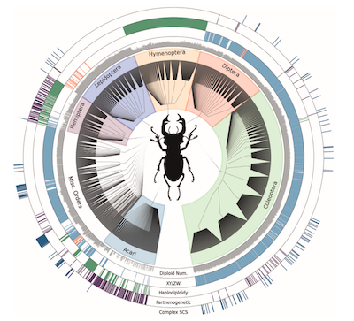

## Graphing environments in R

1. `base`
2. `lattice`
3. `ggplot2`

## Types of plots

[Types of graphs](http://coleoguy.github.io/SWC/example.plots.pptx)

## Data for afternoon

This data is from a study of the impact of using computers to take notes in a classroom. It includes the score students made on a test plus the method they used for taking notes and their sex.

scores.csv

## Challenge 1

Make a mosaic plot that shows the relationship between passing (at least 70%) and using a computer. You will have to munge your data to make a contingency table and then use `mosaicplot`

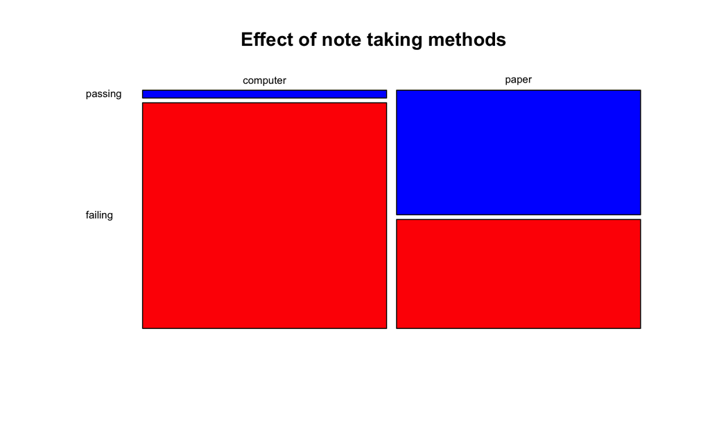

## Challenge 2

Load the old faithful dataset `data(faithful)` and use what you have learned to create a plot. Try using `plot`, `abline`, `lm`. Make sure to make it more awesome than this:

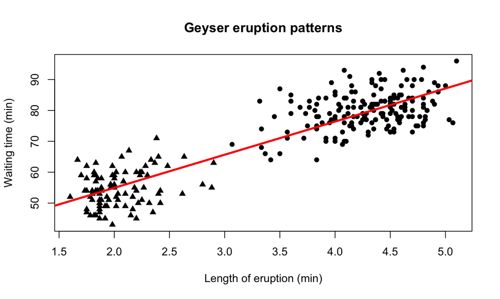